# Rail Trail t Test

```r
library(tidyverse)
library(mosaic)
library(reshape2)
library(plotly)
library(pander)
```

```r
railtrail <- RailTrail %>%
  mutate(
    Weekday = case_when(
      dayType == "weekday" ~ 1,
      TRUE                 ~ 0
    ),
    Weekend = case_when(
      dayType == "weekend" ~ 1,
      TRUE                 ~ 0
    )
  ) %>%
  select(-c(weekday, dayType))
```

## Introduction

The following analysis was done with the Rail Trail data set. Below is a description of this data set from its mosaicData help page.

The Pioneer Valley Planning Commission (PVPC) collected data north of Chestnut Street in Florence, MA for ninety days from April 5, 2005 to November 15, 2005. Data collectors set up a laser sensor, with breaks in the laser beam recording when a rail-trail user passed the data collection station.

There is a potential for error when two users trigger the infrared beam at exactly the same time since the counter would only logs one of the crossings. The collectors left the motion detector out during the winter, but because the counter drops data when the temperature falls below 14 degrees Fahrenheit, there is no data for the cold winter months.

## Hypotheses:

$H_0: \mu_1 - \mu_2 = 0$  
$H_a: \mu_1 - \mu_2 \neq 0$

## Analysis

### Scatter Plot and Trend Line

Here is a scatter plot of the volume and high temperature of each day data was collected. I included a trendline to show the trend of the data points. You can see there seems to be a pattern, with the volume of visitors increasing with the high temperatures. Let’s perform a test in search of some evidence.

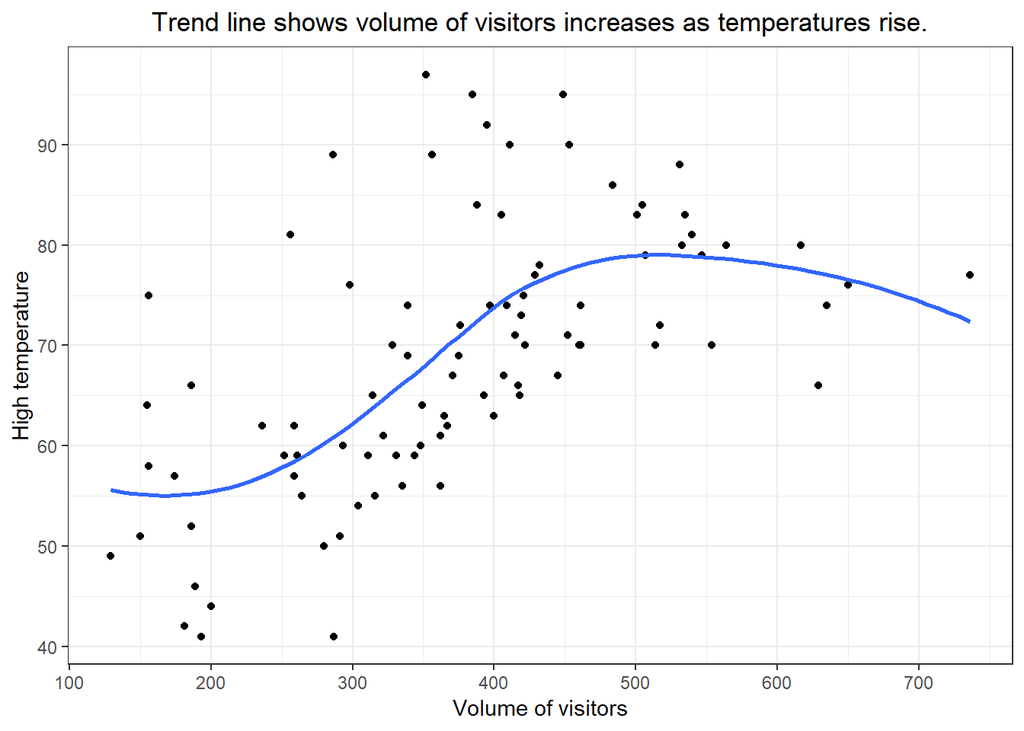

```r
# Faceted Density Plot
railtrail %>%
  ggplot(aes(x = volume, y = hightemp)) +
  geom_point() +
  geom_smooth(se = FALSE) +
  scale_y_continuous(breaks = seq(40,100,by = 10)) +
  scale_x_continuous(breaks = seq(100,800,by = 100)) +
  theme_bw() +
  theme(plot.title = element_text(hjust = 0.5)) +
  labs(
    title = "Trend line shows volume of visitors increases as temperatures rise.",
    x = "Volume of visitors",
    y = "High temperature"
  )
```

```r
# Student's t-Test
pander(t.test(railtrail$volume, railtrail$hightemp, mu = 0, alternative = "two.sided"))
```

Welch Two Sample t-test: `railtrail$volume` and `railtrail$hightemp` (continued below)

| Test statistic | df | P value | Alternative hypothesis | mean of x |
| --- | --- | --- | --- | --- |
| 22.7 | 90.86 | 3.267e-39 * * * | two.sided | 375.4 |

| mean of y |
| --- |
| 68.83 |

### Pearson’s Correlation Coefficient

[Pearson’s Correlation Coefficient](https://www.statisticshowto.datasciencecentral.com/probability-and-statistics/correlation-coefficient-formula/) is a statistical measurement of the strength of a relationship. The number could be positive or negative, depending on the type of relationship between variables. When I say “relationship”“, I refer to how the change in one variable can cause a change in another. Below, I constructed a correlation matrix which shows how the variables in the Rail Trail data set relates to each other.

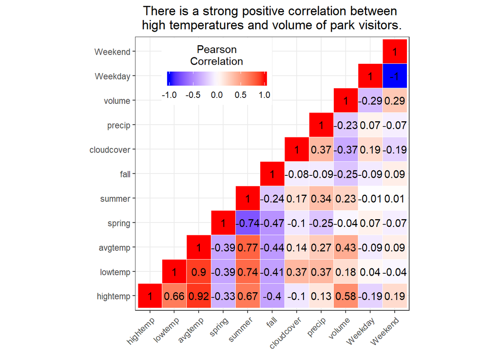

```r
# Step 1
cormat_trail <- round(cor(railtrail),2)

# Step 2
melted_cormat <- melt(cormat_trail)

# Step 3
get_upper_tri <- function(data_set){
  data_set[lower.tri(data_set)] <- NA
  return(data_set)
}

upper_tri_trai <- get_upper_tri(cormat_trail)
melted_upper_tri <- melt(upper_tri_trai, na.rm = TRUE)

# Step 4
ggplot(data = melted_upper_tri, aes(Var2, Var1, fill = value)) +
  geom_tile(color = "white") +
  geom_text(aes(label = value), color = "black") +
  scale_fill_gradient2(low = "blue", high = "red", mid = "white",
                       midpoint = 0, limit = c(-1, 1), space = "lab",
                       name = "Pearson\nCorrelation") +
  theme_bw() +
  theme(plot.title = element_text(hjust = 0.5),
        axis.title.x = element_blank(),
        axis.title.y = element_blank(),
        legend.justification = c(1, 0),
        legend.position = c(0.50, 0.75),
        legend.direction = "horizontal",
        axis.text.x = element_text(angle = 45, hjust = 1)) +
  guides(fill = guide_colorbar(barwidth = 7, barheight = 1,
                               title.position = "top", title.hjust = 0.5)) +
  coord_fixed() +
  labs(
    title = "There is a strong positive correlation between \nhigh temperatures and volume of park visitors.",
    x = "",
    y = ""
  )
```

As you can see, there seems to be a positive correlation between high temperatures and volume of visitors. The correlation seems to be high in comparison to some of the other variables.